# Multivariate Analysis

2nd assignment Cadiou

23/02/2022

# Theorical part

### Join density

We have the uniform distribution of the random vector $(X,Y)^T$ over the set $M=\{(x,y)\in \mathbb{R}^2 ; 0<x<y<1 \}$.

We know that the density function of a random vector $Z$ who follows an uniform distribution on a set $D$ has the form :

$f_{Z}(z) = 1/(Area(D)) * \mathbb{1}_{z \in D}(z)$

Therefore, the density function of the random vector $(X,Y)^T$ is :

$$f_{(X,Y)} (x,y) = 1/(Area(M)) * \mathbb{1} _{(x,y) \in M}(x,y)$$
$$f_{(X,Y)} (x,y) = 1/(1/2) * \mathbb{1} _{(x,y) \in M} (x,y)$$
$$f_{(X,Y)} (x,y) = 2 * \mathbb{1} _{(x,y) \in M}(x,y)$$

### Marginal densities

We can now find the marginal densities of the random vectors $X$ and $Y$.

$f_{X}(x) = \int f_{(X,Y)} (x,y) \, \mathrm{d}y$

$f_{X}(x) = \int 2 * \mathbb{1} _{(x,y) \in M}(x,y) \, \mathrm{d}y$

$f_{X}(x) = \int_x^1 2 * \mathbb{1}_{0<x<y}(x) \mathrm{d}y$

$f_{X}(x) = [2y]_x^1 * \mathbb{1}_{0<x<y}(x)$

$f_{X}(x) = (2 - 2x) * \mathbb{1}_{0<x<y}(x)$

Similarly, we can calculate the marginal density of $Y$ :

$f_{Y}(y) = \int f_{(X,Y)} (x,y) \, \mathrm{d}x$

$f_{Y}(y) = \int 2 * \mathbb{1} _{(x,y) \in M}(x,y) \, \mathrm{d}x$

$f_{Y}(y) = \int_0^y 2 * \mathbb{1}_{x<y<1}(y) \mathrm{d}x$

$f_{Y}(x) = [2y]_0^y * \mathbb{1}_{x<y<1}(y)$

$f_{Y}(x) = 2y * \mathbb{1}_{x<y<1}(y)$

## Independance ?

The first hinch is to say that $X$ and $Y$ can not be independant because the random vector $(X,Y)^T$ is defined on $M$, and $M$ is constructed on $X$ depending on $Y$ (or on $Y$ depending on $X$).

However, let’s use the theorical definition of independance in a join random vector.

Let’s suppose $(X,Y)^T$ is a join random vector, which density function is $f_{(X,Y)}(x,y)$. $X$ and $Y$ are independant only if :
$$f_{(X,Y)}(x,y) = f_{X}(x) * f_{Y}(y)$$

In our case, we have :
$$f_{X}(x) * f_{Y}(y)=(2 - 2x) * \mathbb{1}_{0<x<y}(x) * f_{Y}(x) = 2y * \mathbb{1}_{x<y<1}(y)$$
$$f_{X}(x) * f_{Y}(y) = (4x-4xy) * \mathbb{1} _{(x,y) \in M}(x,y)$$

Finally,
$$f_{X}(x) * f_{Y}(y) \ne f_{(X,Y)} (x,y)$$

Like it seemed to appeared, $X$ and $Y$ are not independant from each other.

# Practical

## Join density

First of all, let’s create a simulation of the random vector $(X,Y)^T$.

```r
n = 10000

x = rep(0,n)
y = rep(0,n)
random = rep(0,n)
for (i in 1:n){
  random = runif(2,0,1)
  x[i] = min(random)
  y[i] = max(random)
}

X_Y = as.data.frame(cbind(x,y))
head(X_Y)
```

```
##            x         y
## 1 0.43030475 0.8709449
## 2 0.29464446 0.6755050
## 3 0.01867491 0.5154143
## 4 0.39059473 0.4128779
## 5 0.34326436 0.6737392
## 6 0.28222589 0.6742817
```

We can now vizualise the joint density and see if it corresponds to our previous calculation. First of all, let’s plot the $M$ area to be sure it is equal to $1/2$.

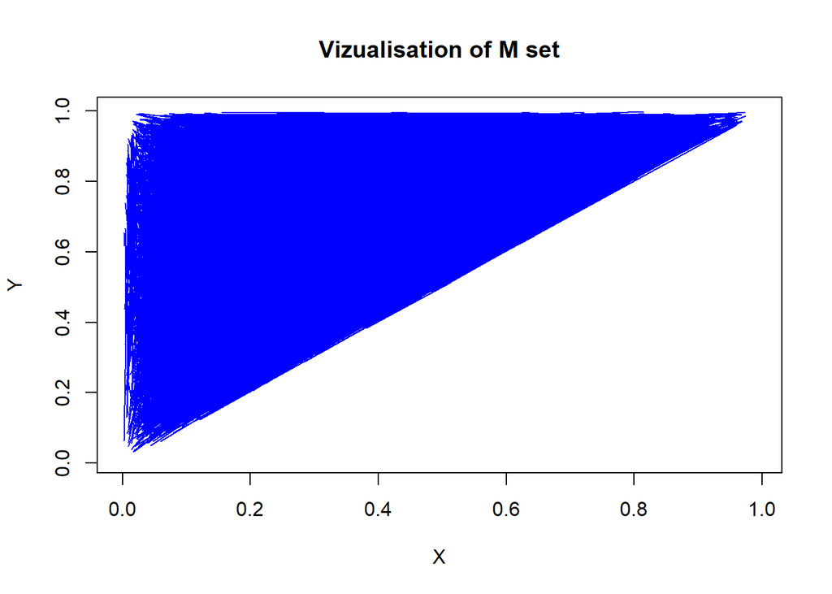

```r
plot(X_Y$x, X_Y$y, type ='c', col ='blue', xlab = "X", ylab = "Y", main = "Vizualisation of M set")
```

It is surely equal to 1/2.

Let’s vizualise the joint density :

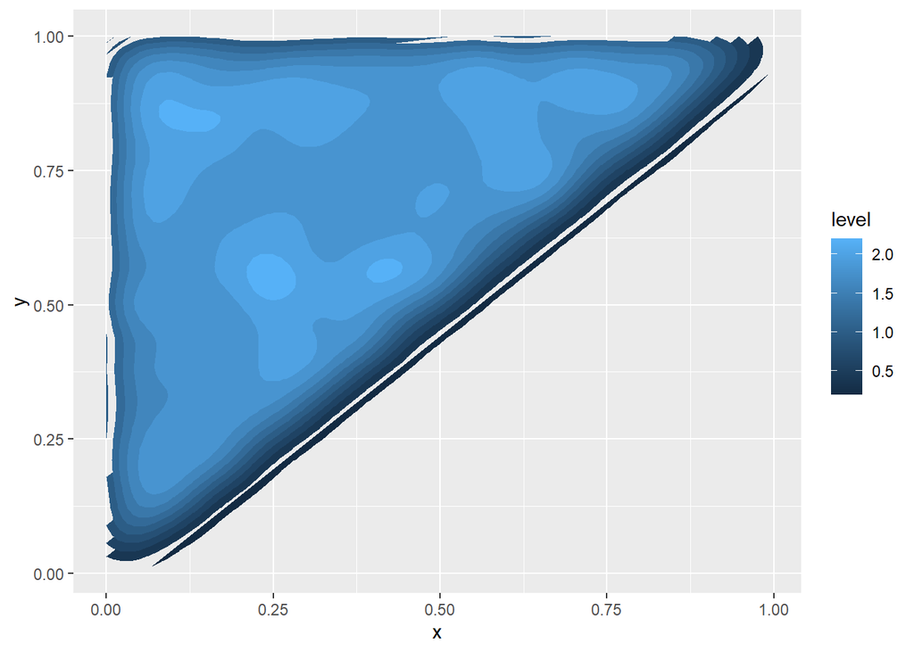

```r
library(ggplot2)
library("MASS")
ggplot(X_Y, aes(x=x, y=y) ) +
  stat_density_2d(aes(fill = ..level..), geom = "polygon")
```

We can see that the density is equal to 2 almost everywhere on the set M. We surely have found the right density expression for the random vector $(X,Y)$.

## Marginal densities

Similarly, we can plot the marginal densities as well as the theorical densities and see how they behave.

To remind, we have found these theorical density functions : $f_{X}(x) = (2 - 2x) * \mathbb{1}_{0<x<y}(x)$ and $f_{Y}(x) = 2y * \mathbb{1}_{x<y<1}(y)$.

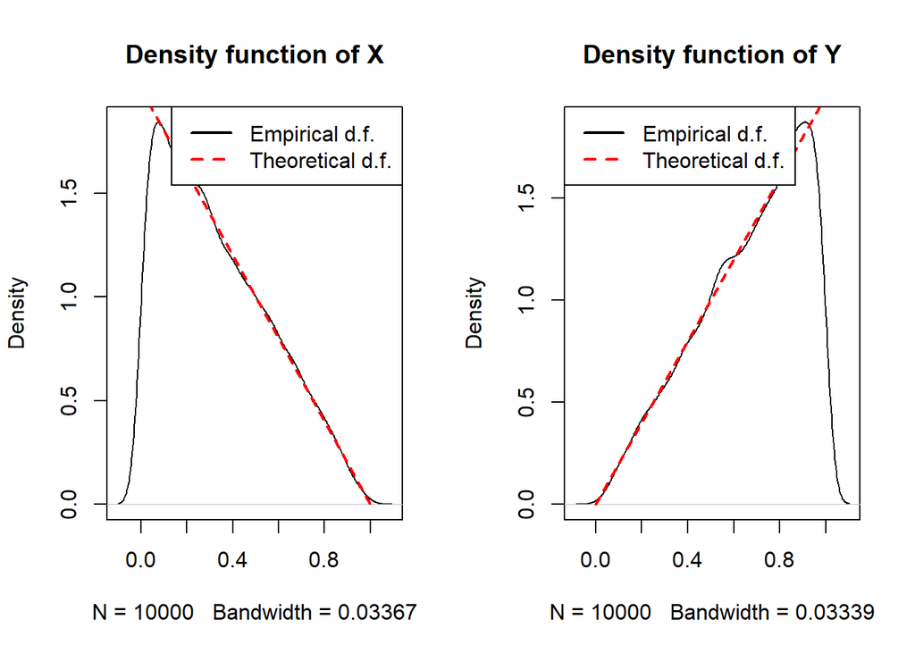

```r
par(mfrow=c(1,2))

xSeq <- seq(0,1, length = n)

plot(density(x), main = "Density function of X")
lines(2-xSeq*2 ~ xSeq, col = "red", lty = 2, lwd = 2)
legend("topright", legend = c("Empirical d.f.", "Theoretical d.f."), col = c("black", "red"), lty = c(1,2), lwd = c(2,2))

plot(density(y), main = "Density function of Y")
lines(2*xSeq ~ xSeq, col = "red", lty = 2, lwd = 2)
legend("topleft", legend = c("Empirical d.f.", "Theoretical d.f."), col = c("black", "red"), lty = c(1,2), lwd = c(2,2))
```

Once again, the graphics correspond to our theorical approach which seem right.

To conclude, we can calculate important sample characteristics (sample means and the sample variance-covariance matrix) :

```r
library(corrplot)
library("eqs2lavaan")
mean(x)
```

```
## [1] 0.3343056
```

```r
mean(y)
```

```
## [1] 0.667885
```

```r
cor(x,y)
```

```
## [1] 0.4915037
```

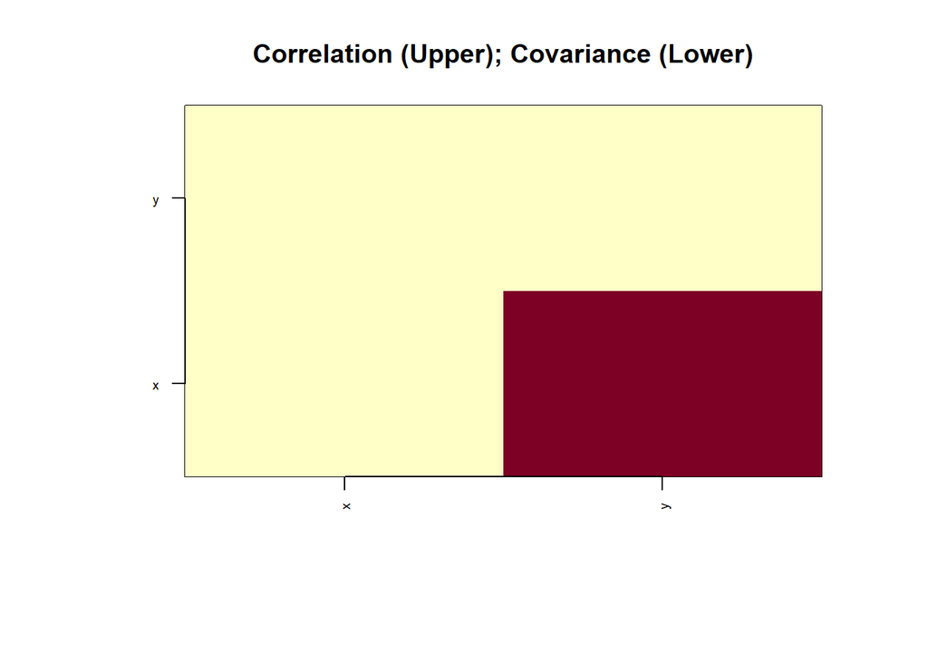

```
##            x          y
## x 0.05571186 0.02715584
## y 0.49150369 0.05479300
```

```r
plotCov(cov(X_Y))
```